# D21009 - D21039 - I2R ET

## Problem Statement

**Goal to predict the patient will get stroke or not by using health care data set.**

## Objective

**Build a classification model to predict by using features from health care data set whether a patient gets stroke or not.**

```r
getwd()                                 #get the working directory
```

```
## [1] "C:/Users/preet/Desktop/R"
```

```r
setwd("C:\\Users\\preet\\Desktop\\R\\End term assignment")  #set the working directory
data = read.csv("healthcare.csv")
View(data)
summary(data)
```

```
##        id           gender               age         hypertension
##  Min.   :   67   Length:5110        Min.   : 0.08   Min.   :0.00000
##  1st Qu.:17741   Class :character   1st Qu.:25.00   1st Qu.:0.00000
##  Median :36932   Mode  :character   Median :45.00   Median :0.00000
##  Mean   :36518                      Mean   :43.23   Mean   :0.09746
##  3rd Qu.:54682                      3rd Qu.:61.00   3rd Qu.:0.00000
##  Max.   :72940                      Max.   :82.00   Max.   :1.00000
##  heart_disease     ever_married        work_type         Residence_type
##  Min.   :0.00000   Length:5110        Length:5110        Length:5110
##  1st Qu.:0.00000   Class :character   Class :character   Class :character
##  Median :0.00000   Mode  :character   Mode  :character   Mode  :character
##  Mean   :0.05401
##  3rd Qu.:0.00000
##  Max.   :1.00000
##  avg_glucose_level     bmi            smoking_status         stroke
##  Min.   : 55.12    Length:5110        Length:5110        Min.   :0.00000
##  1st Qu.: 77.25    Class :character   Class :character   1st Qu.:0.00000
##  Median : 91.89    Mode  :character   Mode  :character   Median :0.00000
##  Mean   :106.15                                          Mean   :0.04873
##  3rd Qu.:114.09                                          3rd Qu.:0.00000
##  Max.   :271.74                                          Max.   :1.00000
```

```r
names(data)
```

```
##  [1] "id"                "gender"            "age"
##  [4] "hypertension"      "heart_disease"     "ever_married"
##  [7] "work_type"         "Residence_type"    "avg_glucose_level"
## [10] "bmi"               "smoking_status"    "stroke"
```

## Variables Details

**ID :** Unique identifier

**Gender:** Gender of the patient

**Age :** Age of the patient

**Hypertension:** It referred as high blood pressure. 0 if he does not has Hypertension and 1 if he has it.

**Heart disease:** 0 if he does not has heart disease and 1 if he has it.

**Ever married:** “Yes” if he is married else “No”.

**Residence Type:** It basically referred as area the patient lives in. Rural and Urban.

**Average Glucose level:** Average glucose level in blood of a patient.

**BMI :** Body mass index of the patient.

**Smoking status:** smoking status of patient. “Formerly smoked”, “Never smoked” and “Smokes”.

**Stroke :** Ultimate target variable which defined by the above variables.

## Hypothesis:

**Id doesn’t affect the patient condition.**

**Gender could affect the patient condition.**

**Age can effect a patient to get stroke.**

**Hypertension could effect the dependent variable stroke.**

**Heart Disease could effect the dependent variable stroke.**

**Marriage could effect the dependent variable stroke.**

**Work type could effect the dependent variable stroke.**

**Residence type could effect the dependent variable stroke.**

**Average glucose level could effect the dependent variable stroke.**

**Body mass index could effect the dependent variable stroke.**

**Smoking status could effect the dependent variable stroke.**

**ID:**

```r
summary(data$id)
```

```
##    Min. 1st Qu.  Median    Mean 3rd Qu.    Max.
##      67   17741   36932   36518   54682   72940
```

```r
is.null(data$id)
```

```
## [1] FALSE
```

**ID is an unique identity to a case**

**Gender**

```r
data$gender = as.factor(data$gender)
summary(data$gender)
```

```
## Female   Male  Other
##   2994   2115      1
```

**Age**

```r
summary(data$age)
```

```
##    Min. 1st Qu.  Median    Mean 3rd Qu.    Max.
##    0.08   25.00   45.00   43.23   61.00   82.00
```

```r
is.null(data$age)
```

```
## [1] FALSE
```

**Hypertension**

```r
data$hypertension = as.factor(data$hypertension)
summary(data$hypertension)
```

```
##    0    1
## 4612  498
```

**Heart Disease**

```r
data$heart_disease = as.factor(data$heart_disease)
summary(data$heart_disease)
```

```
##    0    1
## 4834  276
```

**Ever marries**

```r
data$ever_married = as.factor(data$ever_married)
summary(data$ever_married)
```

```
##   No  Yes
## 1757 3353
```

**Work type**

```r
data$work_type = as.factor(data$work_type)
summary(data$work_type)
```

```
##      children      Govt_job  Never_worked       Private Self-employed
##           687           657            22          2925           819
```

**Residence type**

```r
data$Residence_type = as.factor(data$Residence_type)
summary(data$Residence_type)
```

```
## Rural Urban
##  2514  2596
```

**Average Glucose Level**

```r
summary(data$avg_glucose_level)
```

```
##    Min. 1st Qu.  Median    Mean 3rd Qu.    Max.
##   55.12   77.25   91.89  106.15  114.09  271.74
```

```r
is.null(data$avg_glucose_level)
```

```
## [1] FALSE
```

**BMI**

```r
data$bmi = as.numeric(data$bmi)
summary(data$bmi)
```

```
##    Min. 1st Qu.  Median    Mean 3rd Qu.    Max.    NA's
##   10.30   23.50   28.10   28.89   33.10   97.60     201
```

```r
sum(is.na(data$bmi))
```

```
## [1] 201
```

**NOTE: There are 201 missing values in this variable.**

**Smoking status**

```r
data$smoking_status = as.factor(data$smoking_status)
summary(data$smoking_status)
```

```
## formerly smoked    never smoked          smokes         Unknown
##             885            1892             789            1544
```

**NOTE: There are unknown named category in this variable. We are considering these cases as null values.**

```r
data$smoking_status[data$smoking_status == "Unknown"] = NaN
data$smoking_status = as.character(data$smoking_status)
data$smoking_status = as.factor(data$smoking_status)
summary(data$smoking_status)
```

```
## formerly smoked    never smoked          smokes            NA's
##             885            1892             789            1544
```

**Note: To remove category name “UNKNOWN”, we have changed character into factor.**

**Stroke**

```r
data$stroke = as.factor(data$stroke)
summary(data$stroke)
```

```
##    0    1
## 4861  249
```

## Missing value Imputation.

**Missing value Imputation for BMI**

```r
library(VIM)
data1 = kNN(data, "bmi", k = 5)
summary(data1)
```

```
##        id           gender          age        hypertension heart_disease
##  Min.   :   67   Female:2994   Min.   : 0.08   0:4612       0:4834
##  1st Qu.:17741   Male  :2115   1st Qu.:25.00   1: 498       1: 276
##  Median :36932   Other :   1   Median :45.00
##  Mean   :36518                 Mean   :43.23
##  3rd Qu.:54682                 3rd Qu.:61.00
##  Max.   :72940                 Max.   :82.00
##  ever_married         work_type    Residence_type avg_glucose_level
##  No :1757     children     : 687   Rural:2514     Min.   : 55.12
##  Yes:3353     Govt_job     : 657   Urban:2596     1st Qu.: 77.25
##               Never_worked :  22                  Median : 91.89
##               Private      :2925                  Mean   :106.15
##               Self-employed: 819                  3rd Qu.:114.09
##                                                   Max.   :271.74
##       bmi                smoking_status stroke    bmi_imp
##  Min.   :10.30   formerly smoked: 885   0:4861   Mode :logical
##  1st Qu.:23.70   never smoked   :1892   1: 249   FALSE:4909
##  Median :28.10   smokes         : 789            TRUE :201
##  Mean   :28.92   NA's           :1544
##  3rd Qu.:33.00
##  Max.   :97.60
```

**NOTE: Imputed missing values using KNN**

**Missing value imputation for smoking_status**

```r
newdata = kNN(data1, "smoking_status", k = 5)
summary(newdata$smoking_status)
```

```
## formerly smoked    never smoked          smokes
##            1109            3084             917
```

**NOTE: Imputed missing values using KNN**

```r
newdata = subset(newdata,select = -c(bmi_imp,smoking_status_imp))
View(newdata)
```

**NOTE: Removing two extra columns which are created during imputation of missing values.**

## Univariate Analysis.

**GENDER**

```r
summary(newdata$gender)
```

```
## Female   Male  Other
##   2994   2115      1
```

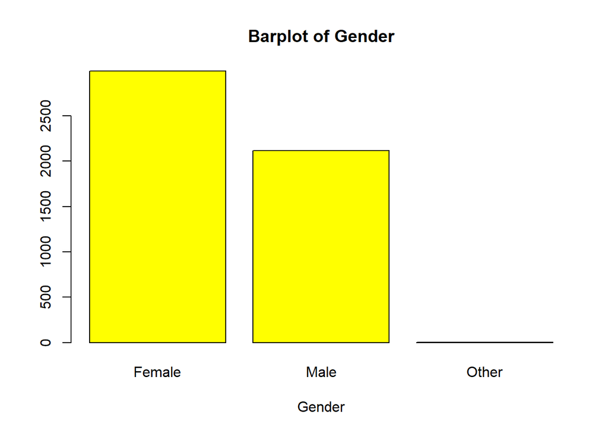

```r
barplot(table(newdata$gender),xlab = "Gender",
        main = "Barplot of Gender",
        col = "yellow")
```

**AGE**

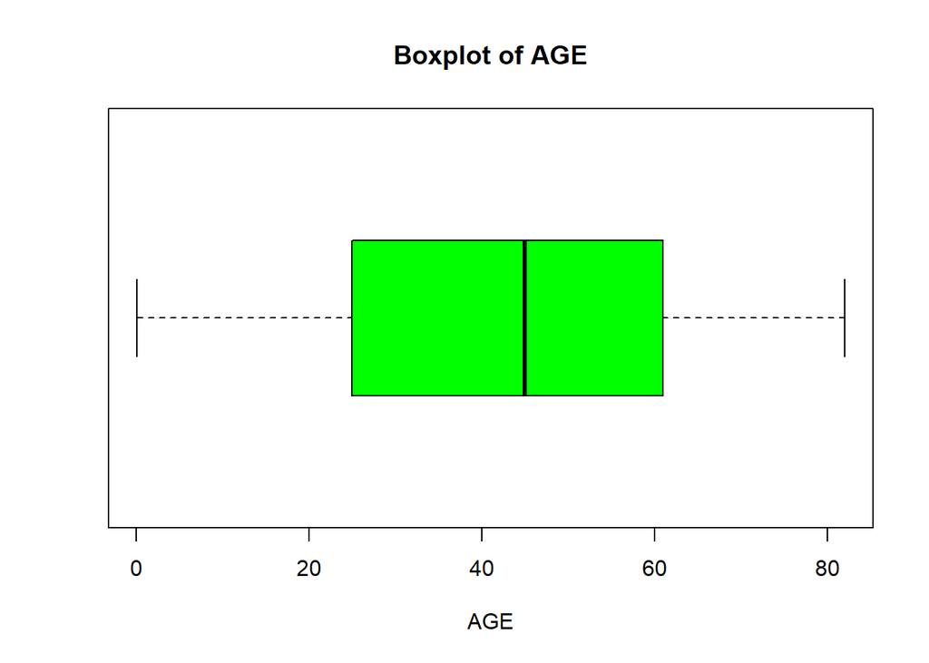

```r
boxplot(newdata$age, xlab = "AGE",
        main = "Boxplot of AGE",
        horizontal = T,
        col = "green")
```

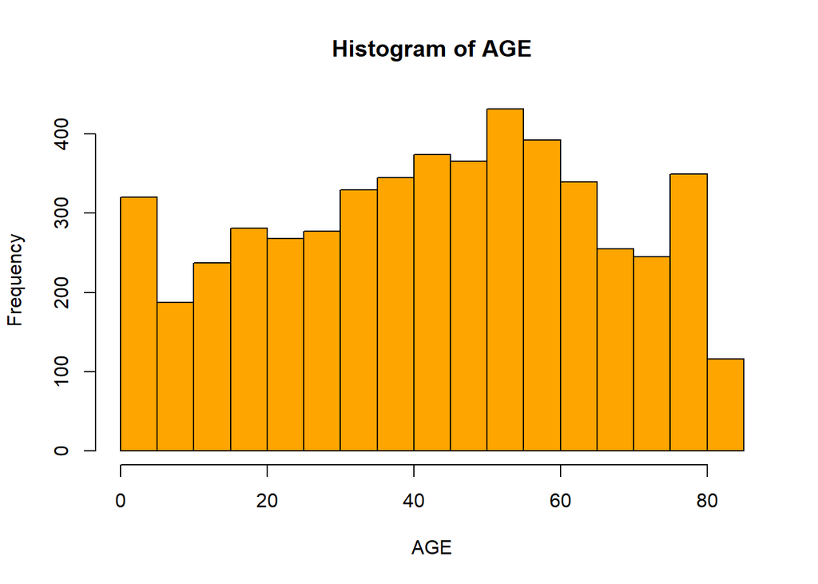

```r
hist(newdata$age, xlab = "AGE",
     main = "Histogram of AGE",
     col = "orange")
```

```r
library(moments)

skewness(newdata$age)
```

```
## [1] -0.1370191
```

**Hypertension**

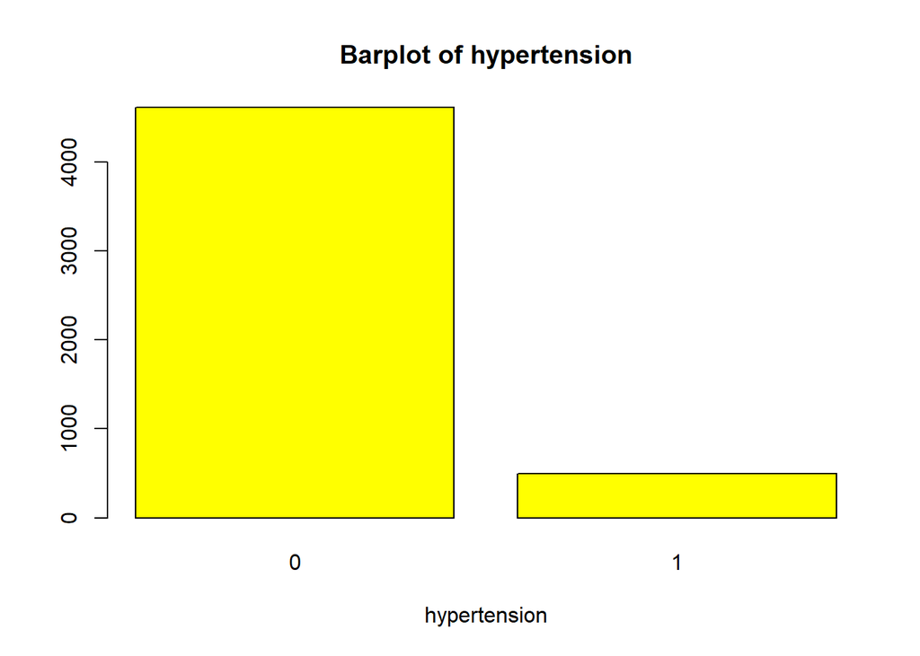

```r
barplot(table(newdata$hypertension),xlab = "hypertension",
        main = "Barplot of hypertension",
        col = "yellow")
```

```r
sum(newdata$hypertension == 1)/nrow(newdata)*100
```

```
## [1] 9.745597
```

**Observations: There are more people with no hypertension and less poeple with hypertension i.e.,9.7%**

**Heart Disease**

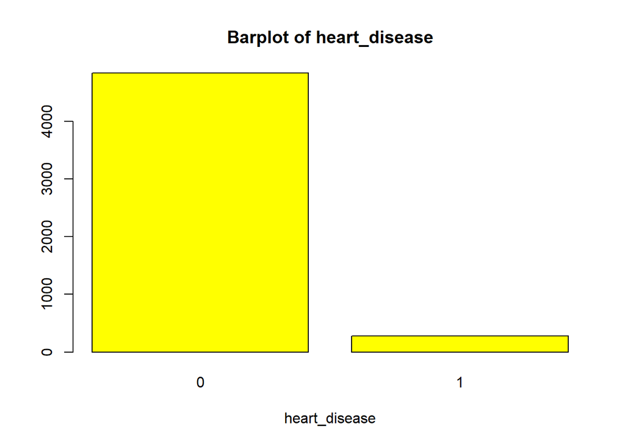

```r
barplot(table(newdata$heart_disease),xlab = "heart_disease",
        main = "Barplot of heart_disease",
        col = "yellow")
```

```r
sum(newdata$heart_disease == 1)/nrow(newdata)*100
```

```
## [1] 5.401174
```

**Observations: 5.4% people has heart disease and remaining do not have hear disease.**

**Ever Married**

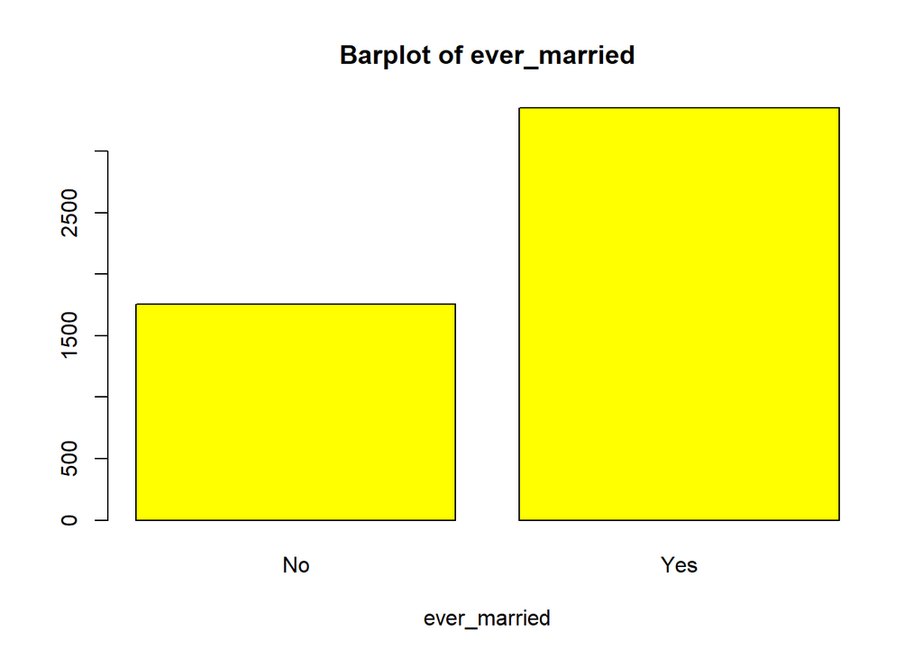

```r
barplot(table(newdata$ever_married),xlab = "ever_married",
        main = "Barplot of ever_married",
        col = "yellow")
```

```r
sum(newdata$ever_married == "Yes")/nrow(newdata)*100
```

```
## [1] 65.61644
```

**Observations: 1/3rd of people are unmarried and 2/3rd are married.**

**Work Type**

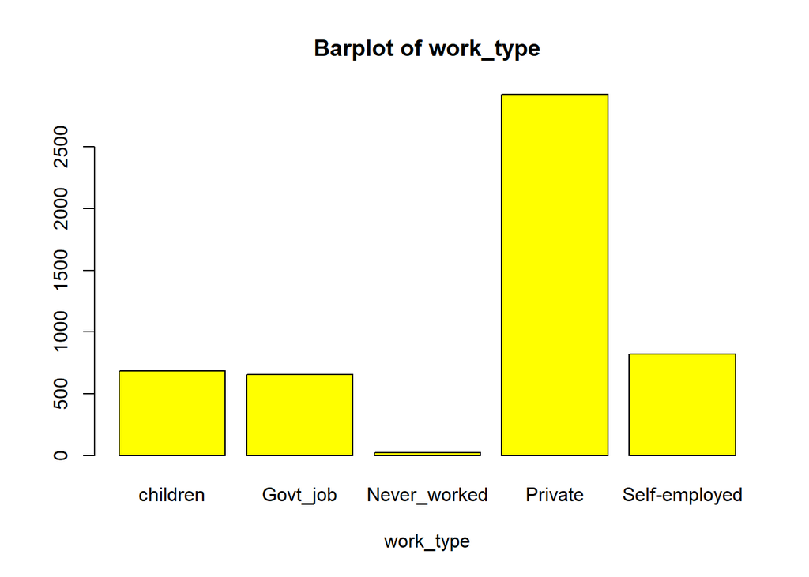

```r
barplot(table(newdata$work_type),xlab = "work_type",
        main = "Barplot of work_type",
        col = "yellow")
```

```r
sum(newdata$work_type == "Private")/nrow(newdata)*100
```

```
## [1] 57.2407
```

**Observations: 0.4% of people are not working and highest are private employees with 57%. Government employees, Children and self employed share almost similar percentages.**

**Residence type**

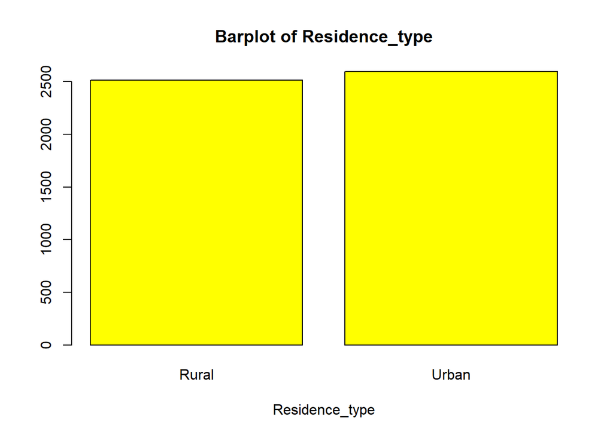

```r
barplot(table(newdata$Residence_type),xlab = "Residence_type",
        main = "Barplot of Residence_type",
        col = "yellow")
```

```r
sum(newdata$Residence_type == "Urban")/nrow(newdata)*100
```

```
## [1] 50.80235
```

**Observations: Approximately 50:50 ratio of urban and rural people.**

**Average Glucose Level**

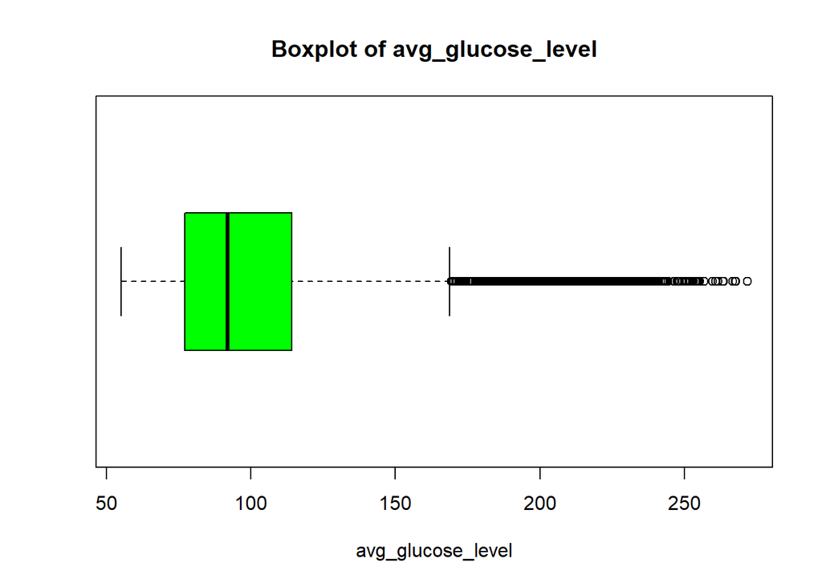

```r
boxplot(newdata$avg_glucose_level, xlab = "avg_glucose_level",
        main = "Boxplot of avg_glucose_level",
        horizontal = T,
        col = "green")
```

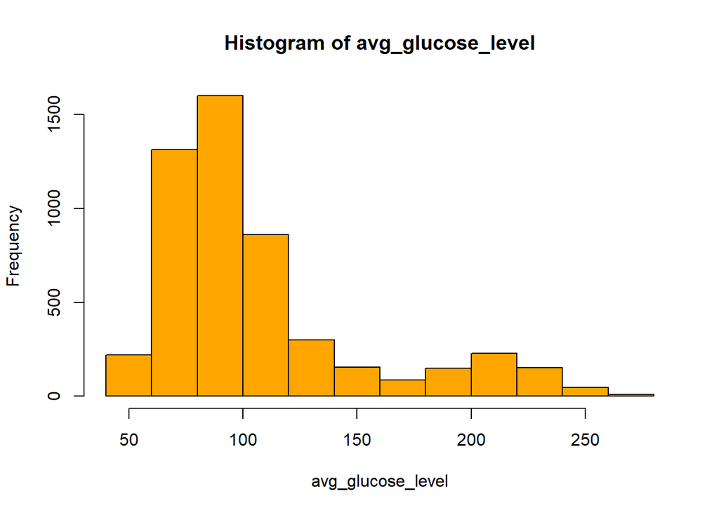

```r
hist(newdata$avg_glucose_level, xlab = "avg_glucose_level",
     main = "Histogram of avg_glucose_level",
     col = "orange")
```

```r
skewness(newdata$avg_glucose_level)
```

```
## [1] 1.571822
```

**Observations: More outliers are present in this variable using boxplot.it is right skewed and value is above 1.5. so we can prefer feature transformation.**

**BMI**

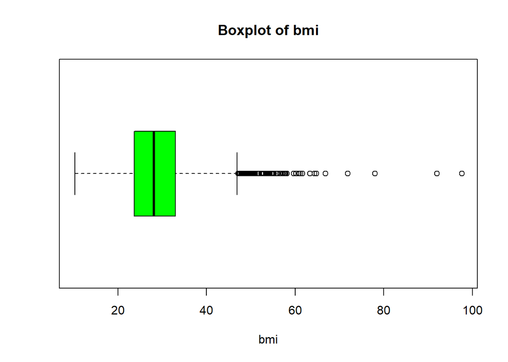

```r
boxplot(newdata$bmi, xlab = "bmi",
        main = "Boxplot of bmi",
        horizontal = T,
        col = "green")
```

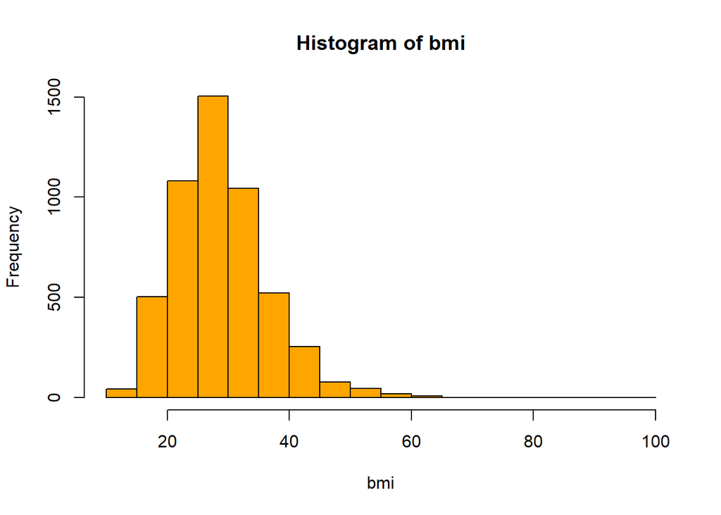

```r
hist(newdata$bmi, xlab = "bmi",
     main = "Histogram of bmi",
     col = "orange")
```

```r
skewness(newdata$bmi)
```

```
## [1] 1.044361
```

***Observations: by plotting boxplot outliers are found and skewness is 1.04.**

**Smoking Status**

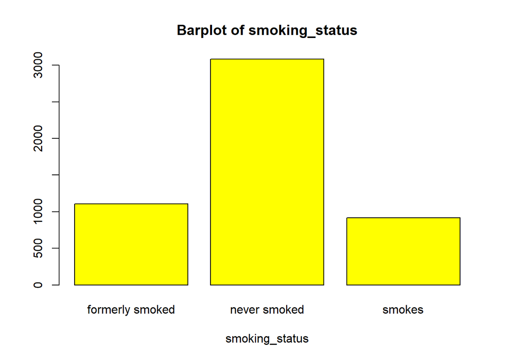

```r
barplot(table(newdata$smoking_status),xlab = "smoking_status",
        main = "Barplot of smoking_status",
        col = "yellow")
```

```r
sum(newdata$smoking_status == "formerly smoked")/nrow(newdata)*100
```

```
## [1] 21.70254
```

```r
sum(newdata$smoking_status == "never smoked")/nrow(newdata)*100
```

```
## [1] 60.35225
```

```r
sum(newdata$smoking_status == "smokes")/nrow(newdata)*100
```

```
## [1] 17.94521
```

**Observations: Never smoked takes the percentage with 60% compared to formerly smoked and smokes.**

**Stroke**

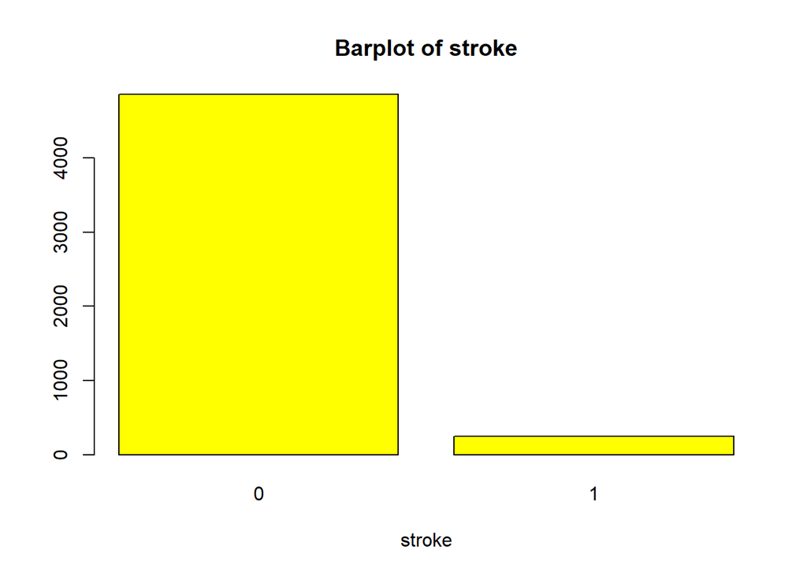

```r
barplot(table(newdata$stroke),xlab = "stroke",
        main = "Barplot of stroke",
        col = "yellow")
```

**Observations: Very less people are having chance to get stroke . so class imbalance is needed to give the equal weightage to these two categories.**

## Bi-variate Analysis.

**Age vs Stroke**

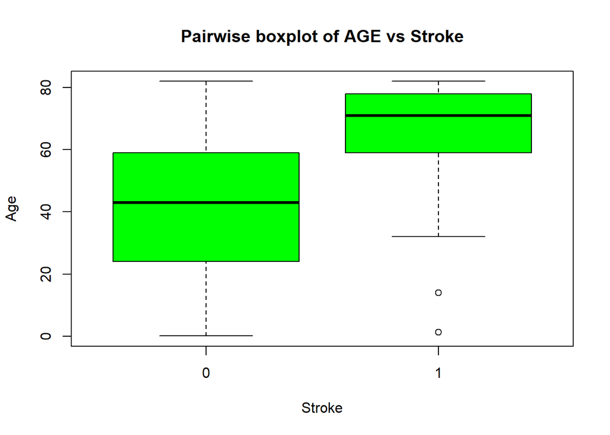

```r
boxplot(newdata$age ~ newdata$stroke, xlab = "Stroke",
        ylab = "Age",
        main = "Pairwise boxplot of AGE vs Stroke",
        horizontal = F,
        col = "green")
```

**Observations:** 1.25% of people getting stroke are below 60 years. 2.75% of people are not having stroke age is below 60 and at the same time 75% of people having stroke age is above 60. 3.50% of people not having stroke are below approximately 42 years and 50% of people getting stroke are above approximately 70 years.

**Avg Glucose level vs Stroke**

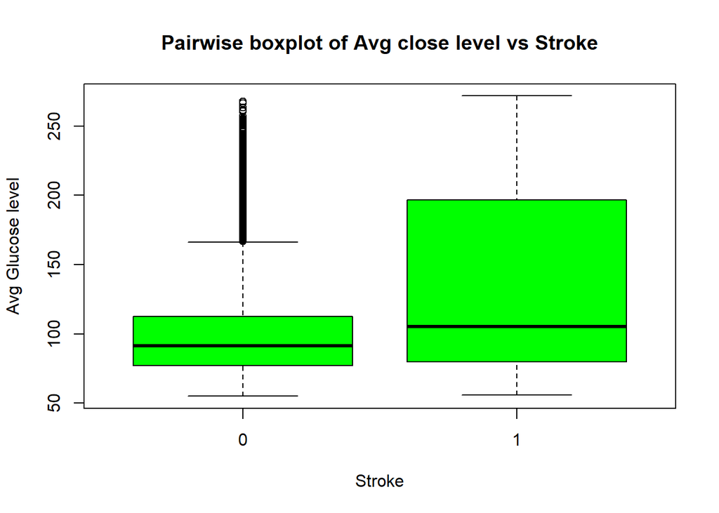

```r
boxplot(newdata$avg_glucose_level ~ newdata$stroke, xlab = "Stroke",
        ylab = "Avg Glucose level",
        main = "Pairwise boxplot of Avg close level vs Stroke",
        horizontal = F,
        col = "green")
```

**Observations:** 1.50% of people having stroke has average glucose level is above 100. And 75% of people not having stroke has average gluocose level below 120. 2.Potential outliers are present in avg gluocose level with stroke “0”.

**BMI vs Stroke**

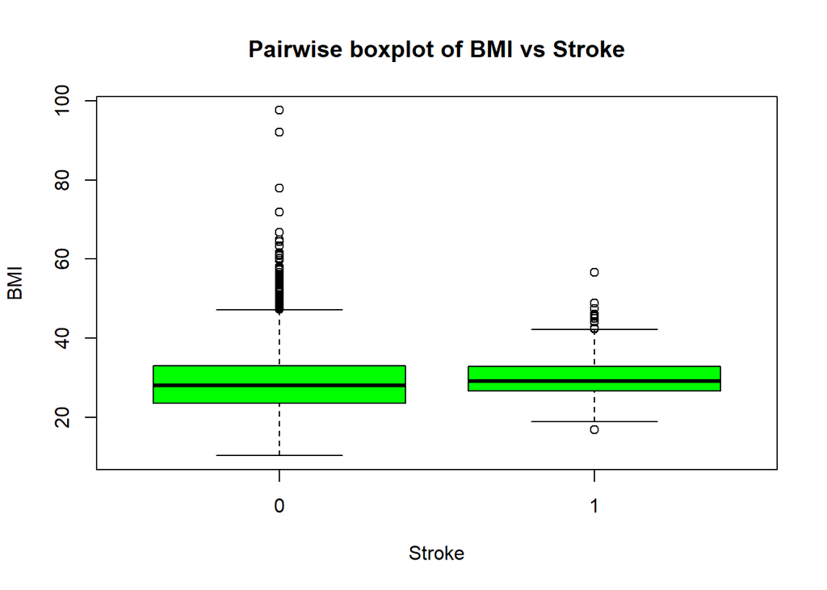

```r
boxplot(newdata$bmi ~ newdata$stroke, xlab = "Stroke",
        ylab = "BMI",
        main = "Pairwise boxplot of BMI vs Stroke",
        horizontal = F,
        col = "green")
```

**Observations:** 1.Both the people with stroke “0” and “1” are having same median,i.e., people are having stroke and not having stroke have the same bmi. 2.Both are having potential outliers.

## Outlier detection

**We are finding outliers to numerical variables.** **There are 3 numerical variables “AGE”, “AVERAGE GLUCOSE LEVEL” AND “BMI”.** **By using box plot we detected outliers.**

**AGE**

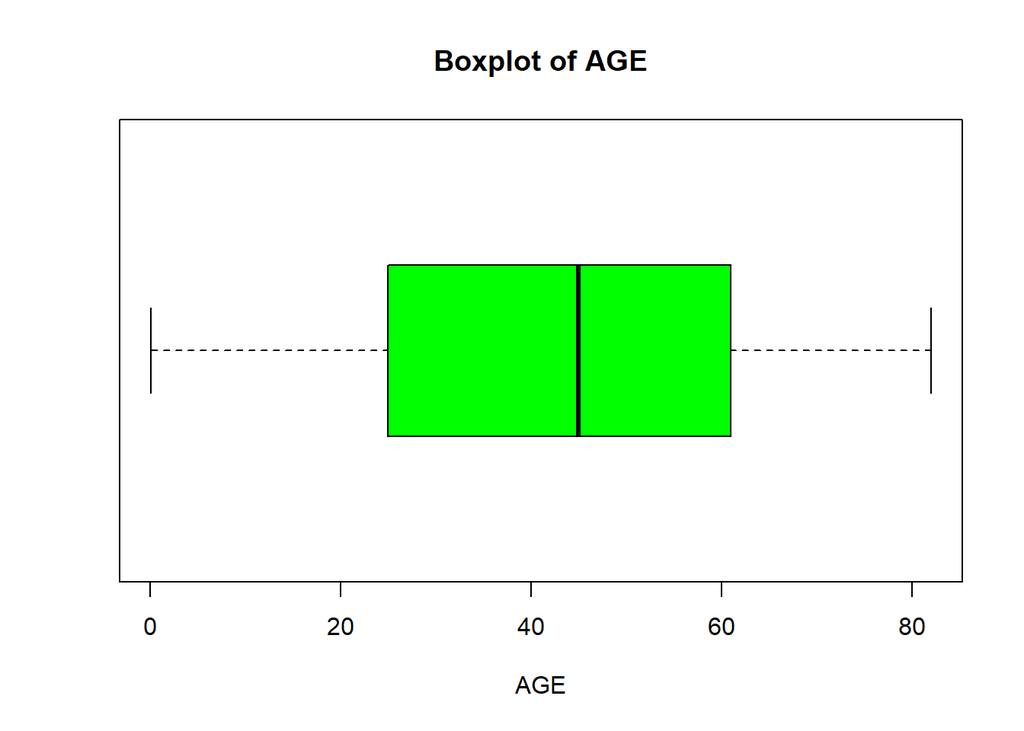

```r
boxplot(newdata$age, xlab = "AGE",
        main = "Boxplot of AGE",
        horizontal = T,
        col = "green")
```

**Observations:No outliers presents in the numerical variable “AGE”.**

**Average Glucose Level**

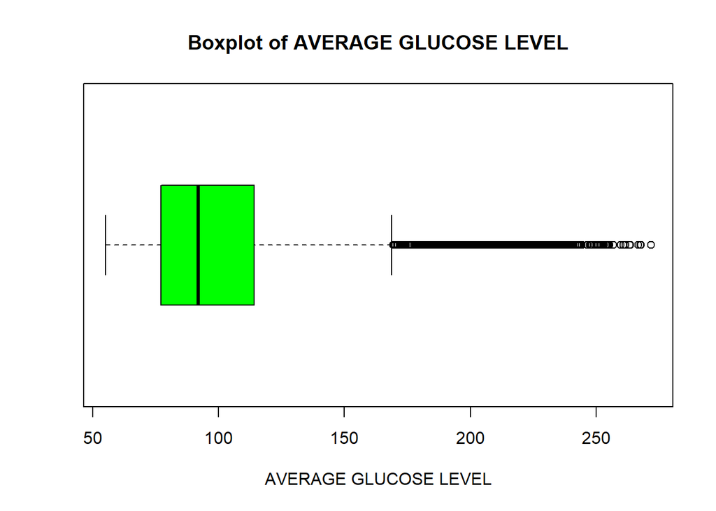

```r
boxplot(newdata$avg_glucose_level, xlab = "AVERAGE GLUCOSE LEVEL",
        main = "Boxplot of AVERAGE GLUCOSE LEVEL",
        horizontal = T,
        col = "green")
```

```r
iqr1 = IQR(newdata$avg_glucose_level)

glucose_outliers = newdata$avg_glucose_level[newdata$avg_glucose_level < quantile(newdata$avg_glucose_level,0.25) - 1.5*iqr1 |
                            newdata$avg_glucose_level > quantile(newdata$avg_glucose_level,0.75) + 1.5*iqr1]

length(glucose_outliers)/nrow(newdata)*100
```

```
## [1] 12.27006
```

**Observations: count of the outliers which are present in the average glucose level is very much high, to be exact we have 12% of data are considered as outliers.**

**BMI**

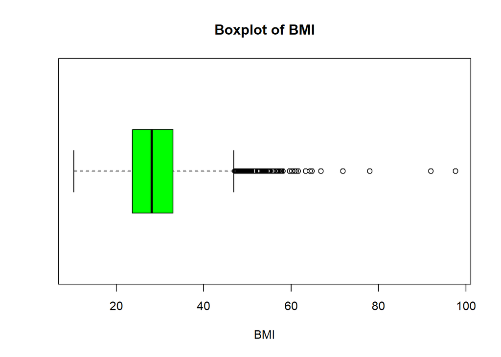

```r
boxplot(newdata$bmi, xlab = "BMI",
        main = "Boxplot of BMI",
        horizontal = T,
        col = "green")
```

```r
iqr2 = IQR(newdata$bmi)

bmi_outliers = newdata$bmi[newdata$bmi < quantile(newdata$bmi,0.25) - 2.5*iqr2 |
                                               newdata$bmi > quantile(newdata$bmi,0.75) + 2.5*iqr2]
bmi_outliers
```

```
##  [1] 56.6 60.9 64.8 60.2 71.9 57.5 78.0 66.8 57.3 57.7 97.6 63.3 61.2 58.1 59.7
## [16] 61.6 57.2 64.4 92.0 57.9 57.2 60.9 56.6
```

```r
length(bmi_outliers)/nrow(newdata)*100
```

```
## [1] 0.4500978
```

## Anomaly Detection

**GENDER**

```r
summary(newdata$gender)
```

```
## Female   Male  Other
##   2994   2115      1
```

```r
other_percentage = (sum(newdata$gender == "Other")/ nrow(newdata))*100
other_percentage
```

```
## [1] 0.01956947
```

**Observations: We have only one case which has gender category is “others” either it has to be wrong entry or if not it could be class imbalance side. So we considered this as anomaly.**

## t-test for numerical variables

```r
t_test = c()
target = newdata$stroke
num_cols = c("age","avg_glucose_level","bmi")

for (x in num_cols)
{
  t = t.test(newdata[,x] ~ target)
  t_test[x] = t$p.value
}


t_test = as.matrix(t_test)
colnames(t_test) = "p-value"
View(t_test)
```

[output not shown]

## Chi-square test for categorical variables

```r
chi_square = c()
target = newdata$stroke

cat_cols = c("gender","hypertension","heart_disease","ever_married","work_type",
         "Residence_type","smoking_status")

for (y in cat_cols)
{
  chi = chisq.test(table(newdata[,y] , target))
  chi_square[y] = chi$p.value
}
chi_square = as.matrix(chi_square)
colnames(chi_square) = "p-value"
View(chi_square)
```

[output not shown]